# India Adaptation Observation Survey Responses, Retrieval Date 15 April 2024.

Autogenerated data summary from dataMaid

2024-04-21 22:27:51.773372

# Data report overview

The dataset examined has the following dimensions:

| Feature | Result |
| --- | --- |
| Number of observations | 1227 |
| Number of variables | 60 |

### Checks performed

The following variable checks were performed, depending on the data type of each variable:

|  | character | factor | labelled | haven labelled | numeric | integer | logical | Date |
| --- | --- | --- | --- | --- | --- | --- | --- | --- |
| Identify miscoded missing values | × | × | × | × | × | × |  | × |
| Identify prefixed and suffixed whitespace | × | × | × | × |  |  |  |  |
| Identify levels with < 6 obs. | × | × | × | × |  |  |  |  |
| Identify case issues | × | × | × | × |  |  |  |  |
| Identify misclassified numeric or integer variables | × | × | × | × |  |  |  |  |
| Identify outliers |  |  |  |  | × | × |  | × |

Please note that all numerical values in the following have been rounded to 2 decimals.

# Summary table

|  | Variable class | # unique values | Missing observations | Any problems? |
| --- | --- | --- | --- | --- |
| start_date | character | 1227 | 0.00 % | × |
| end_date | character | 1225 | 0.00 % | × |
| status | character | 1 | 0.00 % | × |
| ip_address | character | 1207 | 0.00 % | × |
| progress | character | 3 | 0.00 % | × |
| duration_in_seconds | character | 512 | 0.00 % | × |
| finished | character | 2 | 0.00 % |  |
| recorded_date | character | 1225 | 0.00 % | × |
| response_id | character | 1227 | 0.00 % | × |
| recipient_last_name | character | 1 | 100.00 % | × |
| recipient_first_name | character | 1 | 100.00 % | × |
| recipient_email | character | 1 | 100.00 % | × |
| external_reference | character | 1 | 100.00 % | × |
| location_latitude | numeric | 72 | 1.22 % | × |
| location_longitude | numeric | 72 | 1.22 % | × |
| distribution_channel | character | 1 | 0.00 % | × |
| user_language | character | 9 | 0.00 % | × |
| meta_info_browser | character | 4 | 0.00 % | × |
| meta_info_version | character | 77 | 0.00 % | × |
| meta_info_operating_system | character | 20 | 0.00 % | × |
| meta_info_resolution | character | 133 | 0.00 % | × |
| consent_agreed | character | 1 | 0.00 % | × |
| consent_age | character | 1 | 0.00 % | × |
| consent_cellphone | character | 1 | 0.00 % | × |
| gps_permission | character | 1 | 0.00 % | × |
| household_move | character | 3 | 0.08 % |  |
| flood_year | character | 3 | 0.08 % |  |
| property_loss | character | 3 | 71.88 % |  |
| housing_damage | character | 3 | 71.88 % |  |
| stay_residence | character | 3 | 72.05 % |  |
| flood_close | character | 3 | 28.20 % |  |
| flood_prepared | character | 5 | 0.00 % |  |
| housing_safe | character | 6 | 0.24 % |  |
| climate_problem | character | 6 | 0.41 % |  |
| trust_government | character | 6 | 0.16 % |  |
| enough_eat | character | 2 | 0.00 % |  |
| move_rural_urban | character | 2 | 0.00 % |  |
| contact_authority | character | 3 | 0.16 % |  |
| demo_gender | character | 4 | 0.08 % | × |
| demo_age | character | 101 | 0.08 % | × |
| demo_income | character | 302 | 2.61 % | × |
| comp_phone1_try1 | character | 1201 | 0.00 % | × |
| comp_phone1_try2 | character | 1202 | 0.00 % | × |
| comp_phone2_try1 | character | 87 | 92.99 % | × |
| comp_phone2_try2 | character | 90 | 92.75 % | × |
| comp_phone3_try1 | character | 16 | 98.78 % | × |
| comp_phone3_try2 | character | 16 | 98.78 % | × |
| geo_lat | character | 516 | 57.70 % | × |
| geo_lng | character | 515 | 57.70 % | × |
| q_url | character | 1217 | 0.00 % | × |
| q_language | character | 9 | 0.00 % | × |
| gender | character | 3 | 0.57 % |  |
| region | character | 12 | 0.57 % | × |
| age | character | 4 | 0.57 % |  |
| geo_capability | character | 1 | 100.00 % | × |
| geo_status | character | 3 | 0.00 % |  |
| geo_error | character | 2 | 50.86 % | × |
| country | character | 1 | 100.00 % | × |
| no_surverys_submitted | integer | 2 | 0.00 % |  |
| income_brackets | character | 5 | 2.61 % |  |

# Variable list

## start_date

- The variable is a key (distinct values for each observation).

## end_date

| Feature | Result |
| --- | --- |
| Variable type | character |
| Number of missing obs. | 0 (0 %) |
| Number of unique values | 1225 |
| Mode | “2024-03-28 04:51:05” |

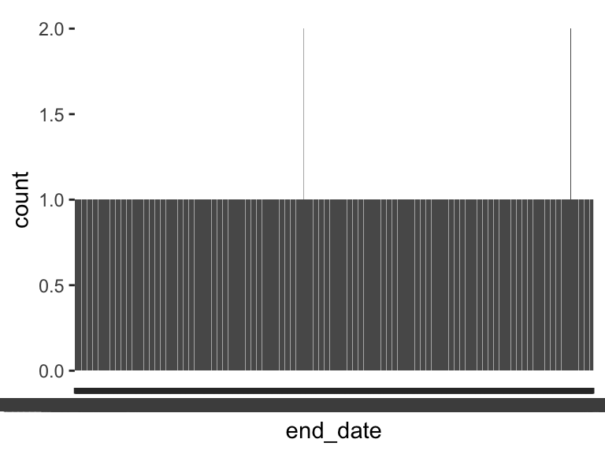

- Note that the following levels have at most five observations: "2024-03-26 19:32:39", "2024-03-26 19:38:38", "2024-03-26 19:40:22", "2024-03-26 19:40:55", "2024-03-26 19:41:11", …, "2024-04-01 03:13:28", "2024-04-01 07:53:47", "2024-04-02 08:30:41", "2024-04-02 16:05:33", "2024-04-06 07:25:16" (1215 values omitted).

## status

- The variable only takes one (non-missing) value: "IP Address". The variable contains 0 % missing observations.

## ip_address

| Feature | Result |
| --- | --- |
| Variable type | character |
| Number of missing obs. | 0 (0 %) |
| Number of unique values | 1207 |
| Mode | “103.85.10.250” |

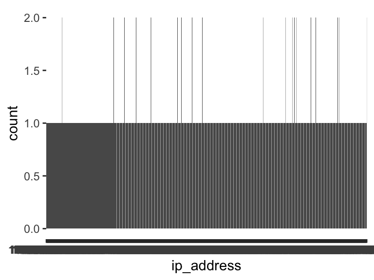

- Note that the following levels have at most five observations: "1.187.142.50", "1.187.180.12", "1.38.104.25", "1.38.105.233", "1.38.105.28", …, "59.95.172.63", "59.95.3.25", "60.243.84.200", "60.254.0.185", "61.1.138.225" (1197 values omitted).

## progress

| Feature | Result |
| --- | --- |
| Variable type | character |
| Number of missing obs. | 0 (0 %) |
| Number of unique values | 3 |
| Mode | “100” |

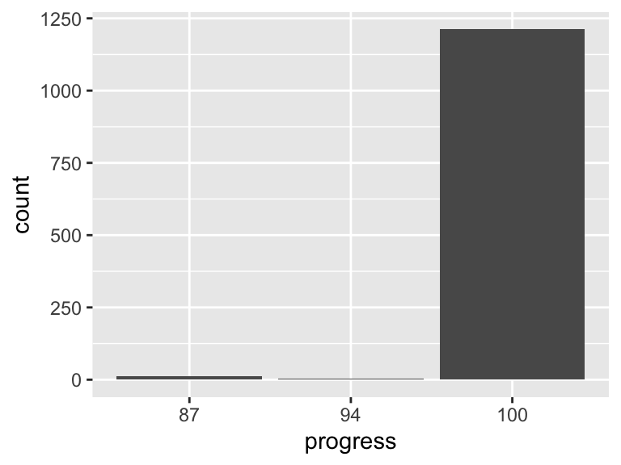

- Note that the following levels have at most five observations: "94".

## duration_in_seconds

| Feature | Result |
| --- | --- |
| Variable type | character |
| Number of missing obs. | 0 (0 %) |
| Number of unique values | 512 |
| Mode | “208” |

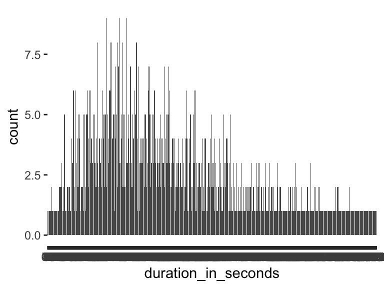

- Note that the following levels have at most five observations: "100", "1021", "104", "1042", "106", …, "946", "955", "9586", "98", "987" (470 values omitted).
- Note: The variable consists exclusively of numbers and takes a lot of different values. Is it perhaps a misclassified numeric variable?

## finished

| Feature | Result |
| --- | --- |
| Variable type | character |
| Number of missing obs. | 0 (0 %) |
| Number of unique values | 2 |
| Mode | “True” |

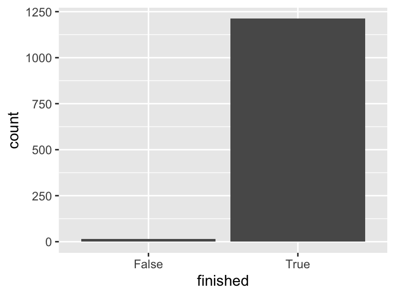

## recorded_date

| Feature | Result |
| --- | --- |
| Variable type | character |
| Number of missing obs. | 0 (0 %) |
| Number of unique values | 1225 |
| Mode | “2024-03-27 01:13:06” |

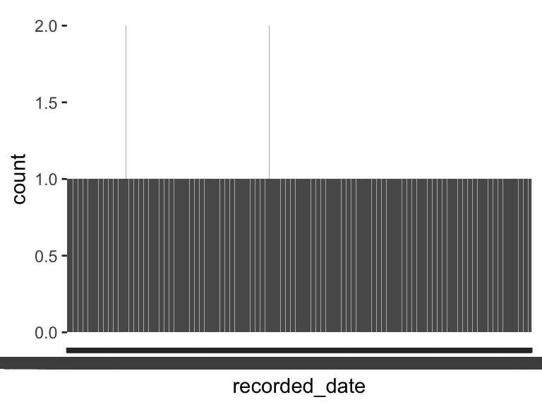

- Note that the following levels have at most five observations: "2024-03-26 19:32:40", "2024-03-26 19:38:39", "2024-03-26 19:40:23", "2024-03-26 19:40:56", "2024-03-26 19:41:12", …, "2024-04-06 07:52:11", "2024-04-06 10:24:31", "2024-04-07 01:06:48", "2024-04-07 07:58:09", "2024-04-07 08:38:30" (1215 values omitted).

## response_id

- The variable is a key (distinct values for each observation).

## recipient_last_name

- The variable only takes one value: "NA".

## recipient_first_name

- The variable only takes one value: "NA".

## recipient_email

- The variable only takes one value: "NA".

## external_reference

- The variable only takes one value: "NA".

## location_latitude

| Feature | Result |
| --- | --- |
| Variable type | numeric |
| Number of missing obs. | 15 (1.22 %) |
| Number of unique values | 71 |
| Median | 22.52 |
| 1st and 3rd quartiles | 14.08; 23.03 |
| Min. and max. | 8.76; 28.65 |

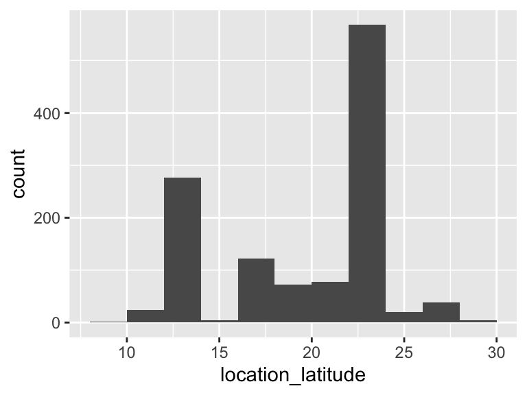

- Note that the following possible outlier values were detected: "23.59", "23.68", "23.73", "23.73", "23.92", …, "26.88", "26.95", "28.61", "28.65", "28.65" (9 values omitted).

## location_longitude

| Feature | Result |
| --- | --- |
| Variable type | numeric |
| Number of missing obs. | 15 (1.22 %) |
| Number of unique values | 71 |
| Median | 73.07 |
| 1st and 3rd quartiles | 72.59; 80.22 |
| Min. and max. | 70.06; 93.94 |

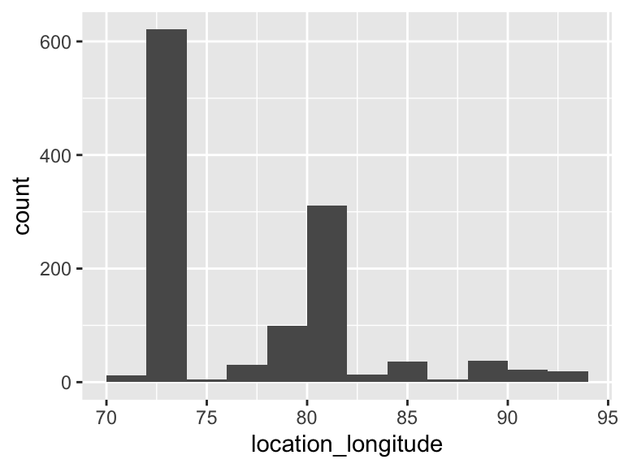

- Note that the following possible outlier values were detected: "70.06", "70.46", "70.79", "70.84", "71.21", "71.81", "72.19".

## distribution_channel

- The variable only takes one (non-missing) value: "anonymous". The variable contains 0 % missing observations.

## user_language

| Feature | Result |
| --- | --- |
| Variable type | character |
| Number of missing obs. | 0 (0 %) |
| Number of unique values | 9 |
| Mode | “EN” |

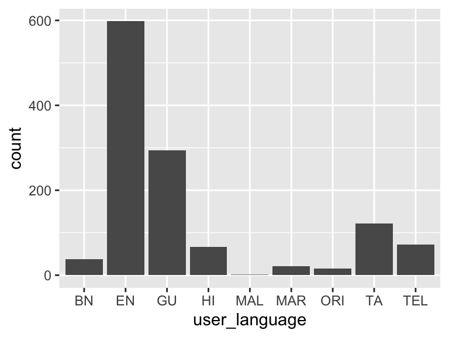

- Note that the following levels have at most five observations: "MAL".

## meta_info_browser

| Feature | Result |
| --- | --- |
| Variable type | character |
| Number of missing obs. | 0 (0 %) |
| Number of unique values | 4 |
| Mode | “Chrome” |

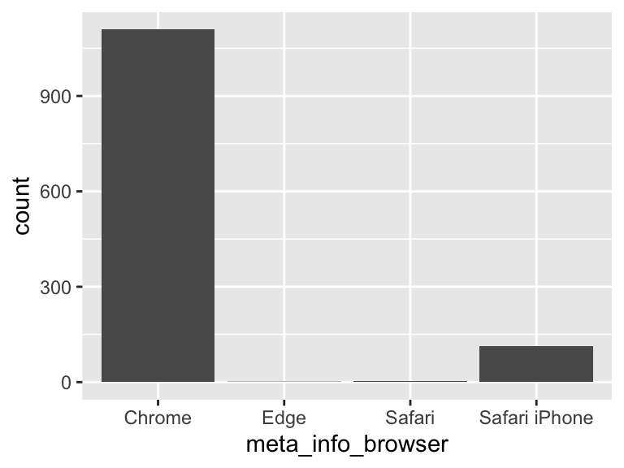

- Note that the following levels have at most five observations: "Edge", "Safari".

## meta_info_version

| Feature | Result |
| --- | --- |
| Variable type | character |
| Number of missing obs. | 0 (0 %) |
| Number of unique values | 77 |
| Mode | “122.0.6261.119” |

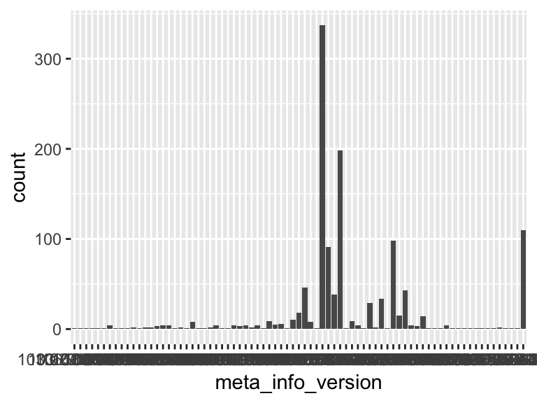

- Note that the following levels have at most five observations: "103.0.5060.129", "103.0.5060.71", "106.0.0.0", "106.0.5249.126", "107.0.5304.141", …, "92.0.4515.131", "93.0.4577.62", "96.0.4664.104", "96.0.4664.45", "99.0.4844.73" (48 values omitted).

## meta_info_operating_system

| Feature | Result |
| --- | --- |
| Variable type | character |
| Number of missing obs. | 0 (0 %) |
| Number of unique values | 20 |
| Mode | “Android 13” |

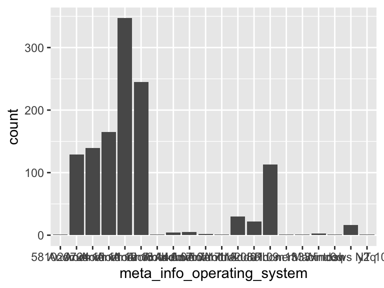

- Note that the following levels have at most five observations: "581020724", "Android 6.0", "Android 7.0", "Android 7.1.1", "Android 7.1.2", …, "m13", "m33x", "Macintosh", "r0q", "y2q" (1 values omitted).

## meta_info_resolution

| Feature | Result |
| --- | --- |
| Variable type | character |
| Number of missing obs. | 0 (0 %) |
| Number of unique values | 133 |
| Mode | “360x800” |

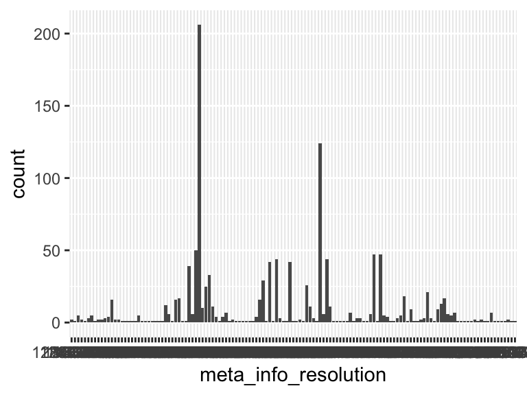

- Note that the following levels have at most five observations: "1280x1024", "1280x720", "1366x768", "1440x900", "1446x704", …, "686x1143", "780x360", "800x1280", "873x393", "876x393" (85 values omitted).

## consent_agreed

- The variable only takes one (non-missing) value: "I agree to participate". The variable contains 0 % missing observations.

## consent_age

- The variable only takes one (non-missing) value: "Yes". The variable contains 0 % missing observations.

## consent_cellphone

- The variable only takes one (non-missing) value: "Yes". The variable contains 0 % missing observations.

## gps_permission

- The variable only takes one (non-missing) value: "Yes". The variable contains 0 % missing observations.

## household_move

| Feature | Result |
| --- | --- |
| Variable type | character |
| Number of missing obs. | 1 (0.08 %) |
| Number of unique values | 2 |
| Mode | “No” |

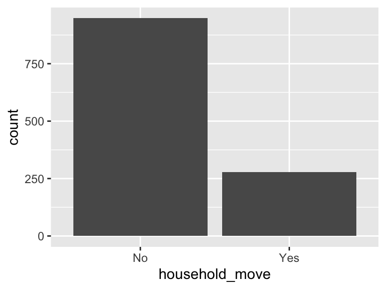

## flood_year

| Feature | Result |
| --- | --- |
| Variable type | character |
| Number of missing obs. | 1 (0.08 %) |
| Number of unique values | 2 |
| Mode | “No” |

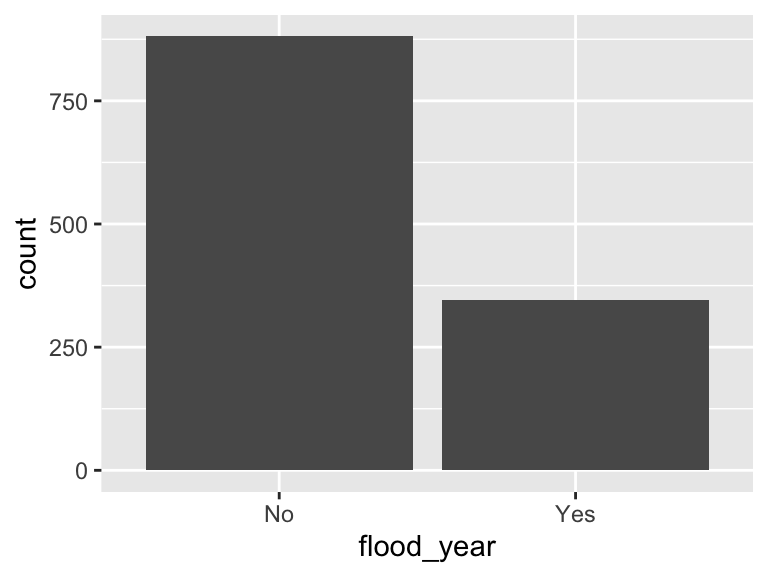

## property_loss

| Feature | Result |
| --- | --- |
| Variable type | character |
| Number of missing obs. | 882 (71.88 %) |
| Number of unique values | 2 |
| Mode | “No” |

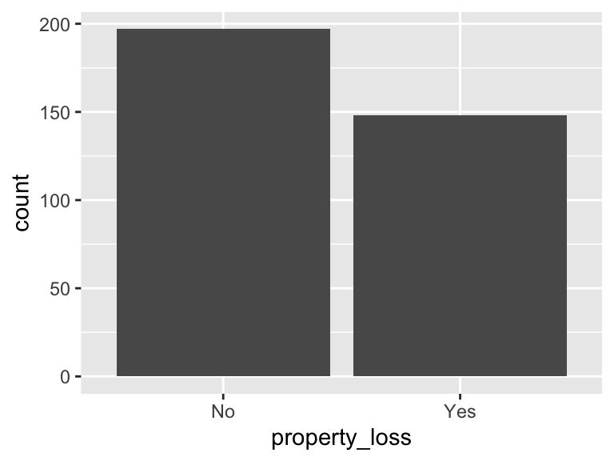

## housing_damage

| Feature | Result |
| --- | --- |
| Variable type | character |
| Number of missing obs. | 882 (71.88 %) |
| Number of unique values | 2 |
| Mode | “Yes” |

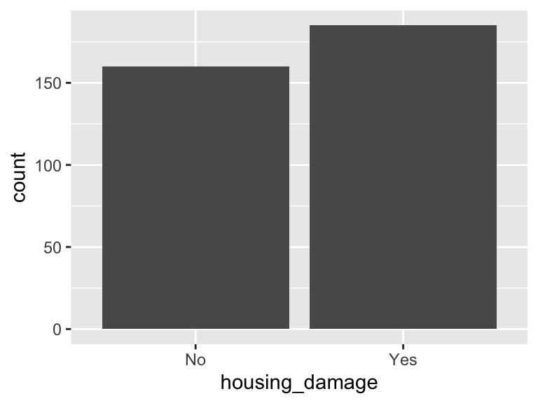

## stay_residence

| Feature | Result |
| --- | --- |
| Variable type | character |
| Number of missing obs. | 884 (72.05 %) |
| Number of unique values | 2 |
| Mode | “Yes” |

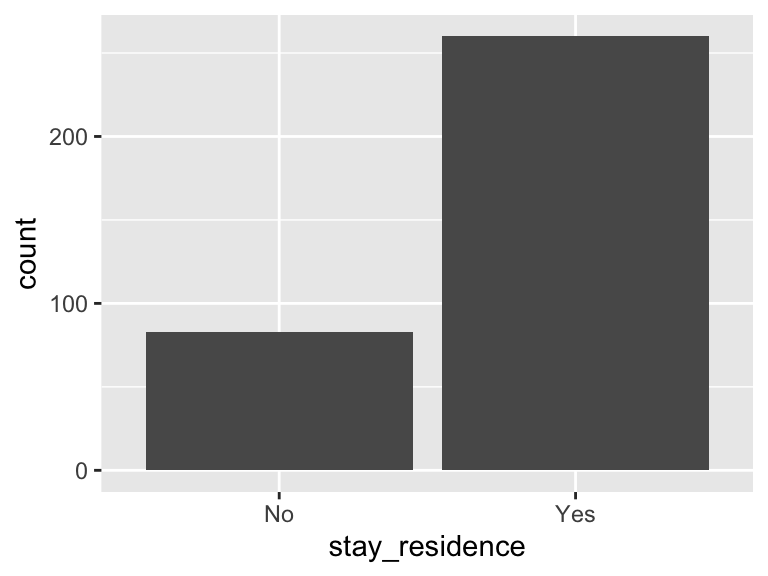

## flood_close

| Feature | Result |
| --- | --- |
| Variable type | character |
| Number of missing obs. | 346 (28.2 %) |
| Number of unique values | 2 |
| Mode | “No” |

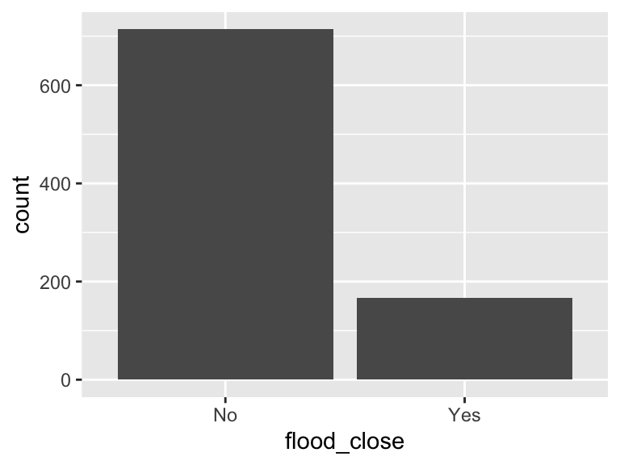

## flood_prepared

| Feature | Result |
| --- | --- |
| Variable type | character |
| Number of missing obs. | 0 (0 %) |
| Number of unique values | 5 |
| Mode | “Strongly agree” |

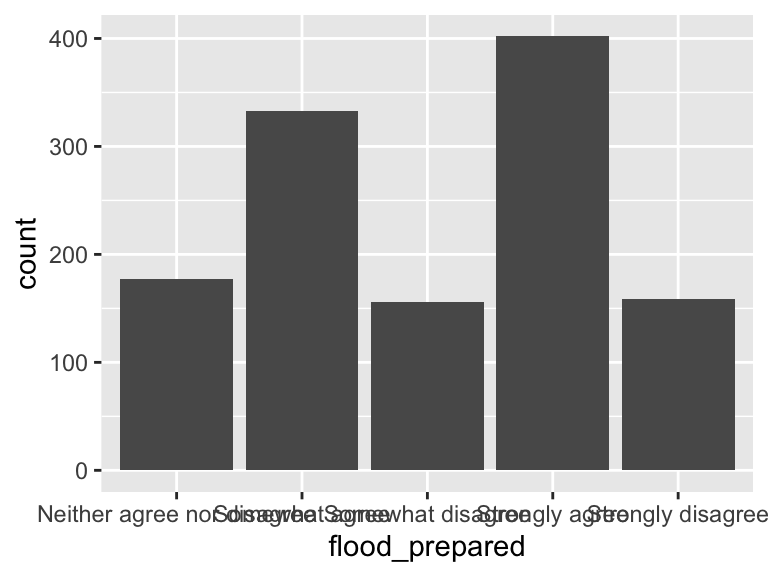

## housing_safe

| Feature | Result |
| --- | --- |
| Variable type | character |
| Number of missing obs. | 3 (0.24 %) |
| Number of unique values | 5 |
| Mode | “Strongly agree” |

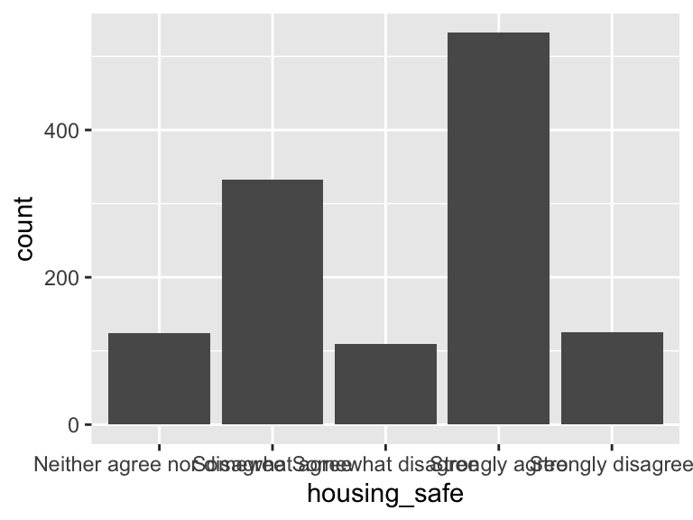

## climate_problem

| Feature | Result |
| --- | --- |
| Variable type | character |
| Number of missing obs. | 5 (0.41 %) |
| Number of unique values | 5 |
| Mode | “Strongly agree” |

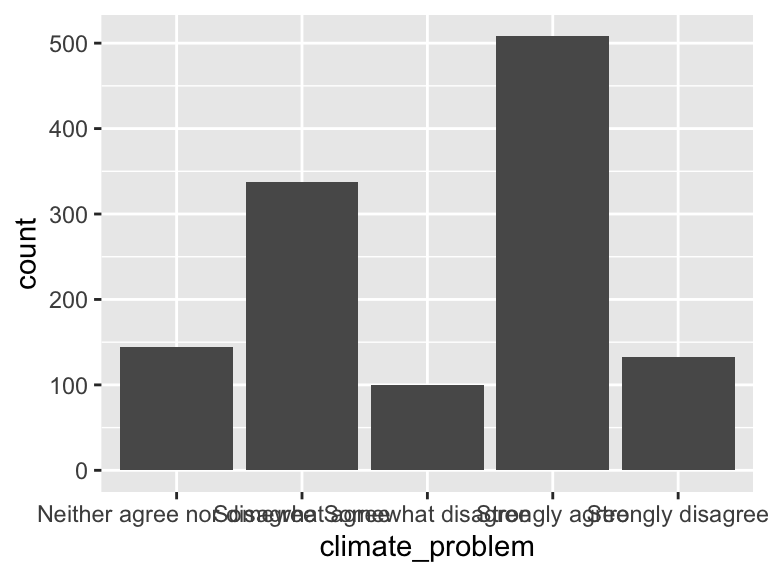

## trust_government

| Feature | Result |
| --- | --- |
| Variable type | character |
| Number of missing obs. | 2 (0.16 %) |
| Number of unique values | 5 |
| Mode | “Strongly agree” |

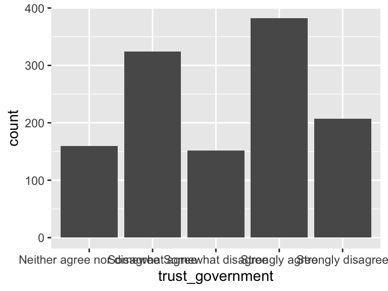

## enough_eat

| Feature | Result |
| --- | --- |
| Variable type | character |
| Number of missing obs. | 0 (0 %) |
| Number of unique values | 2 |
| Mode | “Yes” |

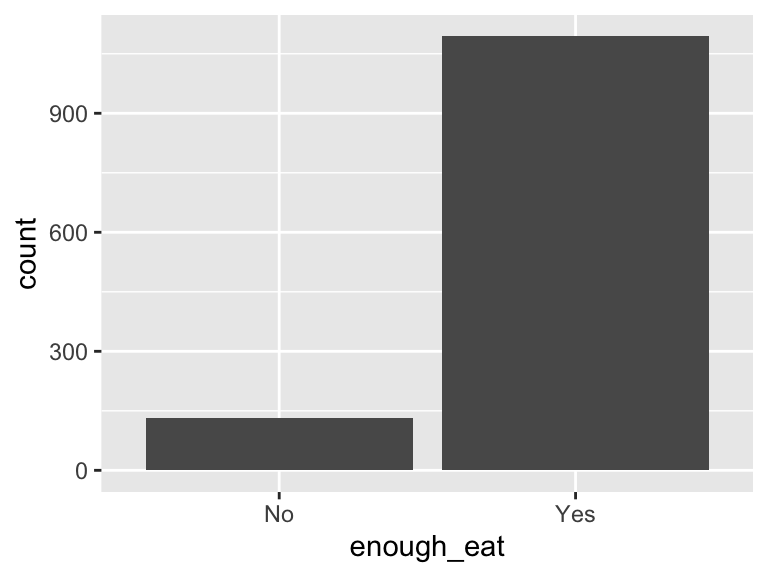

## move_rural_urban

| Feature | Result |
| --- | --- |
| Variable type | character |
| Number of missing obs. | 0 (0 %) |
| Number of unique values | 2 |
| Mode | “Yes” |

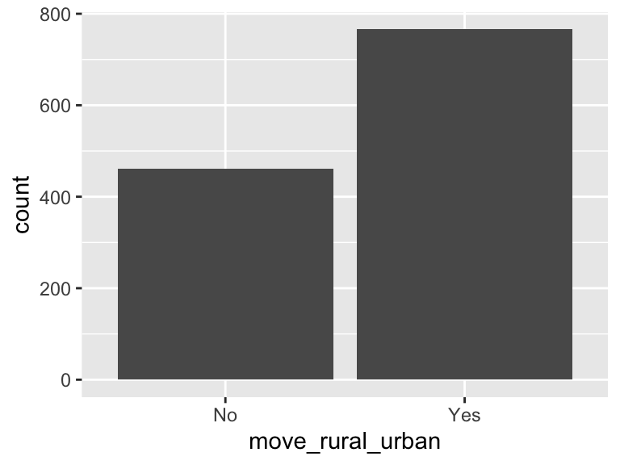

## contact_authority

| Feature | Result |
| --- | --- |
| Variable type | character |
| Number of missing obs. | 2 (0.16 %) |
| Number of unique values | 2 |
| Mode | “No” |

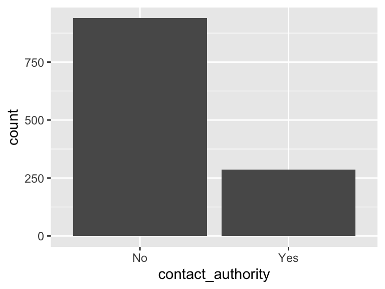

## demo_gender

| Feature | Result |
| --- | --- |
| Variable type | character |
| Number of missing obs. | 1 (0.08 %) |
| Number of unique values | 3 |
| Mode | “Male” |

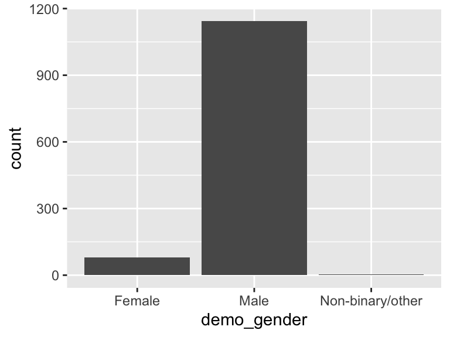

- Note that the following levels have at most five observations: "Non-binary/other".

## demo_age

| Feature | Result |
| --- | --- |
| Variable type | character |
| Number of missing obs. | 1 (0.08 %) |
| Number of unique values | 100 |
| Mode | “30” |

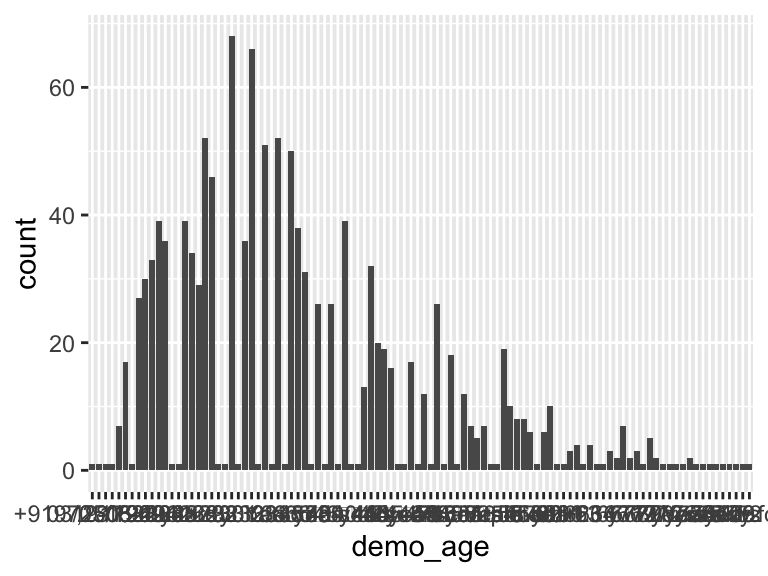

- Note that the following levels have at most five observations: ",28", "+919725033808", "03/05/1969", "17", "19-05-1961", …, "76109", "77", "7752", "78", "Sixty four" (47 values omitted).

## demo_income

| Feature | Result |
| --- | --- |
| Variable type | character |
| Number of missing obs. | 32 (2.61 %) |
| Number of unique values | 301 |
| Mode | “10000” |

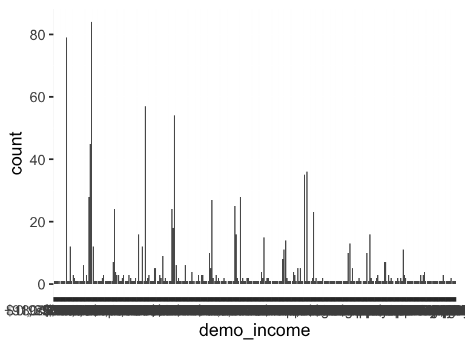

- The following suspected missing value codes enter as regular values: "Na".
- Note that the following levels have at most five observations: ", 29000/-", "+919725033808", "$0", "$120", "$150", …, "জানিনা", "না", "இல்லை", "வருமானம் ஏதும் இல்லை", "లెదు" (254 values omitted).

## comp_phone1_try1

| Feature | Result |
| --- | --- |
| Variable type | character |
| Number of missing obs. | 0 (0 %) |
| Number of unique values | 1201 |
| Mode | “No” |

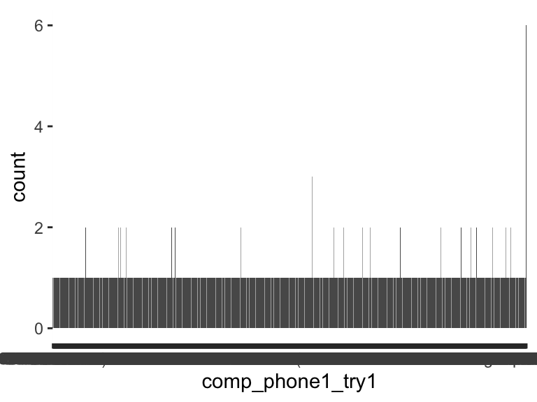

- Note that the following levels have at most five observations: "*91-9989988008", "++91 8779619188", "+91 70059 75018", "+91 7016591708", "+91 7046753102", …, "9998460260", "9999988888", "I pass", "K", "Thanks for including our region in your study prof!" (1190 values omitted).

## comp_phone1_try2

| Feature | Result |
| --- | --- |
| Variable type | character |
| Number of missing obs. | 0 (0 %) |
| Number of unique values | 1202 |
| Mode | “918983057930” |

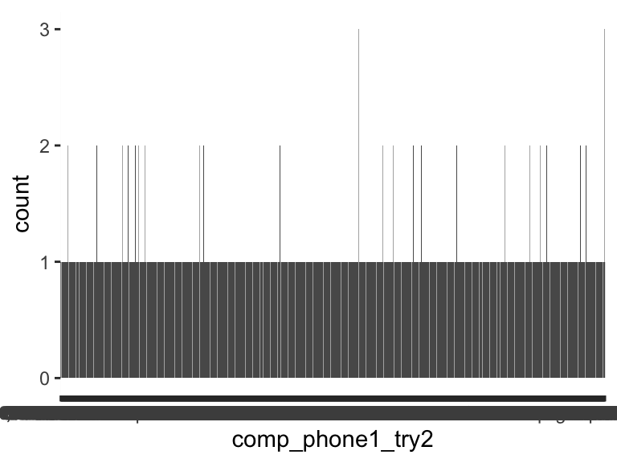

- Note that the following levels have at most five observations: ",8008178324", ",9841404049", "+91 70059 75018", "+91 7016591708", "+91 7046753102", …, "I pass", "K", "No", "Thanks for including our region in your study prof!", "હા" (1192 values omitted).

## comp_phone2_try1

| Feature | Result |
| --- | --- |
| Variable type | character |
| Number of missing obs. | 1141 (92.99 %) |
| Number of unique values | 86 |
| Mode | “+91 8758688414” |

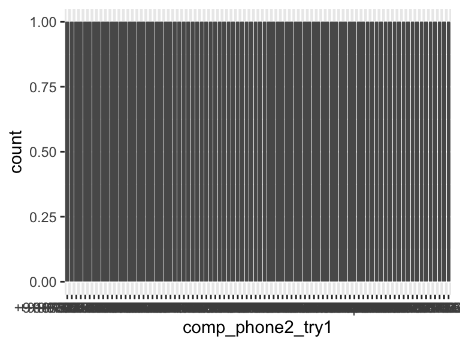

- Note that the following levels have at most five observations: "+91 8758688414", "+91 8780247663", "+916374213067", "+917005746923", "+919440517116", …, "9913194391", "9971573145", "9974483308", "9987759911", "No" (76 values omitted).

## comp_phone2_try2

| Feature | Result |
| --- | --- |
| Variable type | character |
| Number of missing obs. | 1138 (92.75 %) |
| Number of unique values | 89 |
| Mode | “+91 8758688414” |

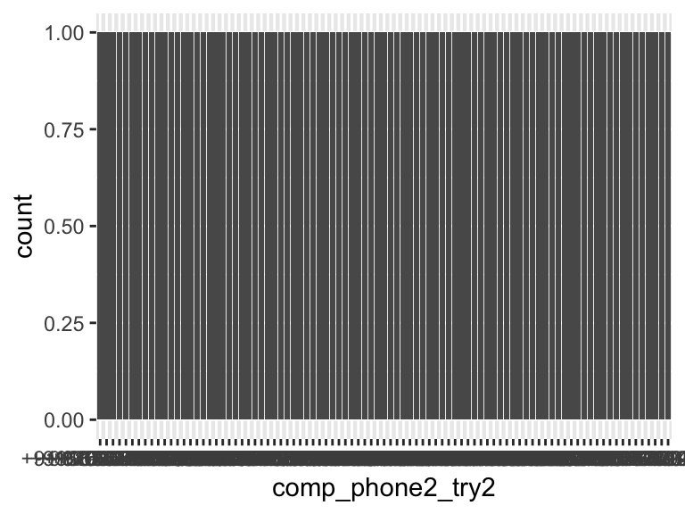

- Note that the following levels have at most five observations: "+91 8758688414", "+916374213067", "+917005746923", "+918780247663", "+919440517116", …, "9971573145", "9974483308", "9987759911", "No", "હા" (79 values omitted).

## comp_phone3_try1

| Feature | Result |
| --- | --- |
| Variable type | character |
| Number of missing obs. | 1212 (98.78 %) |
| Number of unique values | 15 |
| Mode | “6355300098” |

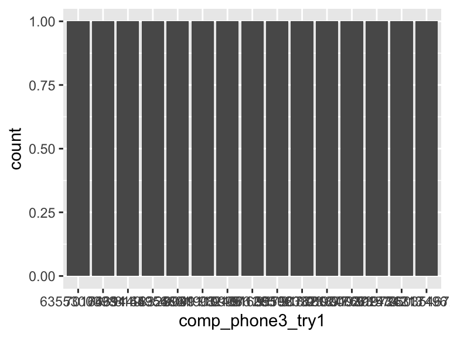

- Note that the following levels have at most five observations: "6355300098", "7016461149", "76394 65354", "8144956601", "8328961903", …, "918780247663", "919000271573", "919392434213", "919726317496", "9503546721" (5 values omitted).

## comp_phone3_try2

| Feature | Result |
| --- | --- |
| Variable type | character |
| Number of missing obs. | 1212 (98.78 %) |
| Number of unique values | 15 |
| Mode | “7016461149” |

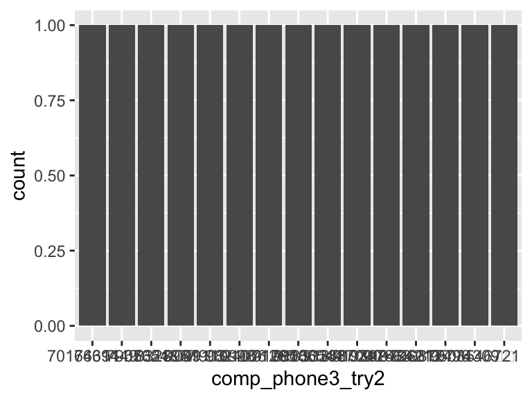

- Note that the following levels have at most five observations: "7016461149", "76394 65354", "7907621877", "8328961903", "9049110998", …, "919392434213", "919726317496", "919879774309", "9503546721", "હા" (5 values omitted).

## geo_lat

| Feature | Result |
| --- | --- |
| Variable type | character |
| Number of missing obs. | 708 (57.7 %) |
| Number of unique values | 515 |
| Mode | “18.9502044” |

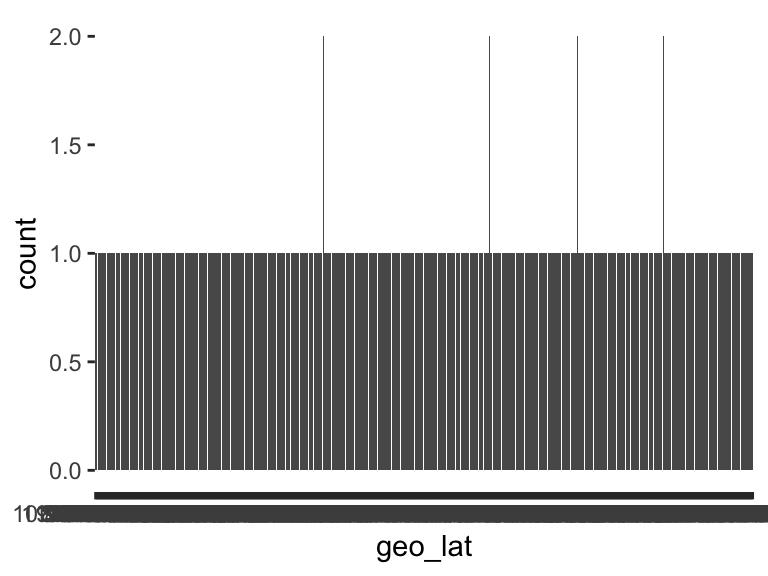

- Note that the following levels have at most five observations: "10.0006676", "10.349449", "10.4866279", "10.6678316", "10.7966026", …, "9.000800129999996", "9.0838393", "9.503249", "9.7219761", "9.9997732" (505 values omitted).
- Note: The variable consists exclusively of numbers and takes a lot of different values. Is it perhaps a misclassified numeric variable?

## geo_lng

| Feature | Result |
| --- | --- |
| Variable type | character |
| Number of missing obs. | 708 (57.7 %) |
| Number of unique values | 514 |
| Mode | “70.8146097” |

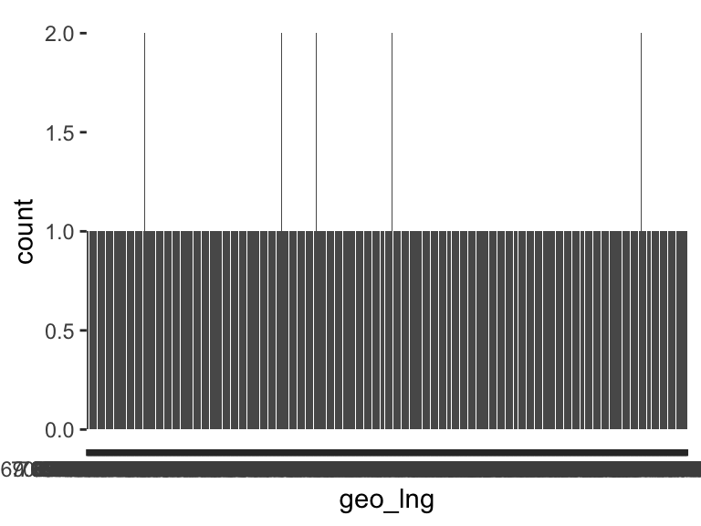

- Note that the following levels have at most five observations: "68.9638325", "69.3546141", "69.3639259", "69.4886958", "69.5681388", …, "91.3003905", "91.3068005", "91.4696038", "91.8128906", "92.1941493" (504 values omitted).
- Note: The variable consists exclusively of numbers and takes a lot of different values. Is it perhaps a misclassified numeric variable?

## q_url

| Feature | Result |
| --- | --- |
| Variable type | character |
| Number of missing obs. | 0 (0 %) |
| Number of unique values | 1217 |
| Mode | “https://ucsb.co1.qualtrics.com/jfe/form/SV_28ZOxlwZy4635uS?Q_Language=EN®ion=Andhra+Pradesh&gender=Male&age=18” |

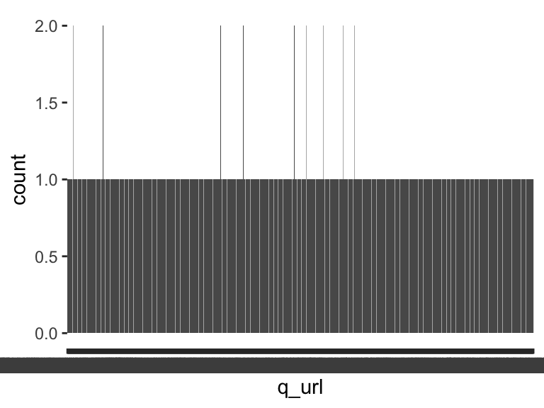

- Note that the following levels have at most five observations: "https://ucsb.co1.qualtrics.com/jfe/form/SV_28ZOxlwZy4635uS?fbclid=IwAR0Dn9I2QuL82a6Q88oood3pApasbwGvVm_h9lZAzUx6mAd8FzcUE9k7Zog\“, "https://ucsb.co1.qualtrics.com/jfe/form/SV_28ZOxlwZy4635uS?fbclid=IwAR1pfHZ6-iRocZ2bPbIUOZASbleOVmE15zSOPltHSsbumTyNCc4AqbLahxY\”, "https://ucsb.co1.qualtrics.com/jfe/form/SV_28ZOxlwZy4635uS?fbclid=IwAR1Tq8ECp3-Qomlp_4JDRXWtdhHFsVyy2kCvYyrNuEW7WJN5gO3ba-46NEg\“, "https://ucsb.co1.qualtrics.com/jfe/form/SV_28ZOxlwZy4635uS?fbclid=IwAR209V33_AwGqrx3a5XlQ2b7KCPLbnmnvwWS2XxeRpjVJjADXEsmZDF9MSM_aem_AX9AHZyEVrfsfsBfH_48n3J3VQFHWXhPZVpCGCA1bLG5d3xj4nUc_qJ1bHBDn4eM6khCVM-OvAxBG3J70uNlLNUo\”, "https://ucsb.co1.qualtrics.com/jfe/form/SV_28ZOxlwZy4635uS?fbclid=IwAR2IqcKrHpvW5O8epjHpHUugkzOSsewRQJ9xAZ_EsVofVBQEi8c3CeYUeNM\“, …, "https://ucsb.co1.qualtrics.com/jfe/form/SV_28ZOxlwZy4635uS?Q_Language=EN®ion=West+Bengal++%28second+half%29&gender=Male&age=50&fbclid=IwAR057VRmqAIWENBr3UqIrGg9uq5vp7r4_Ste2cGml2HR4OVTSWmcoDHPhkU_aem_AWWm7eR3JOhWPJuKQpSqqkcFgmAH39jIFGvRBV_715aGjaRIX7I8RryOg2Exi22XLCmHGqK4Z8uuy1CM1TlNJtH8\”, "https://ucsb.co1.qualtrics.com/jfe/form/SV_28ZOxlwZy4635uS?Q_Language=EN®ion=West+Bengal++%28second+half%29&gender=Male&age=50&fbclid=IwAR1v9oj-ThJwVAOG47VOearNfsp_AGqEYp5eE9raL5DmCnlhyX_96Vp_ELY_aem_AR9Tm-qJCk2kEkWlccnGPl-bFhl_AaEHwDY7ka6wuEQPZFCRGDjrh1gSL-T6bZMxrHnV9j--z1mOLcikZi46z8KJ\“, "https://ucsb.co1.qualtrics.com/jfe/form/SV_28ZOxlwZy4635uS?Q_Language=EN®ion=West+Bengal++%28second+half%29&gender=Male&age=50&fbclid=IwAR29-2dAU8DkrFiAtuVTuwQvLEky-VHtNz9P6YJFRogS6Mhf2xgUtwlGAcM_aem_AWBP8WgjWNhg7vpZvXz1z4G_nu4wT9AWeWGyp0wByYD0EPBAEtK3JYS9gSH0ydEJqF_PiAUUnKacSFTrDxY4IU6y\”, "https://ucsb.co1.qualtrics.com/jfe/form/SV_28ZOxlwZy4635uS?Q_Language=EN®ion=West+Bengal++%28second+half%29&gender=Male&age=50&fbclid=IwAR2GFuMY3kzCbhi_OVVgvCII5H60CU7RKkeNE0_zy395mcyoqFESv4P-mWA_aem_AWekHzvxAGrD2VKjZt8YsglSlWPrTrzS8w0eDqpsLH_9208_ozZSK8JaLHxpi5qGoXn61puV_Hb9u_ybyFdB17fw\“, "https://ucsb.co1.qualtrics.com/jfe/form/SV_28ZOxlwZy4635uS?Q_Language=EN®ion=West+Bengal++%28second+half%29&gender=Male&age=50&fbclid=PAAaYqzjyEfKWL2JyVZZeGk4dWWMVTG5T3RDiGvaqFAaDQf5Zky3qgI9jD9Dc_aem_AWfydDOV75ZCZ-hsjhtpoey1um9kTsu-L6KWFsbQkaN4s90FDtR1hFR9G2al1Ix3VNVljTkCxyGZELOSRwp86cQA\” (1207 values omitted).

## q_language

| Feature | Result |
| --- | --- |
| Variable type | character |
| Number of missing obs. | 0 (0 %) |
| Number of unique values | 9 |
| Mode | “EN” |

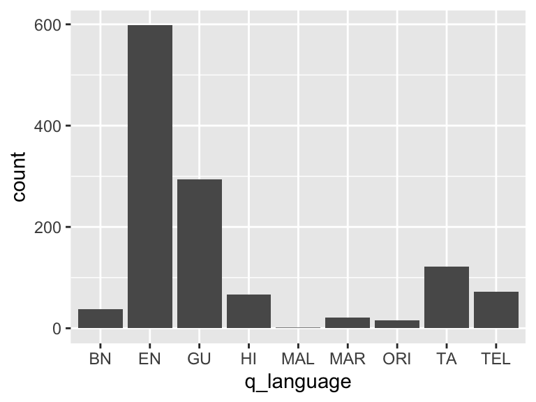

- Note that the following levels have at most five observations: "MAL".

## gender

| Feature | Result |
| --- | --- |
| Variable type | character |
| Number of missing obs. | 7 (0.57 %) |
| Number of unique values | 2 |
| Mode | “Male” |

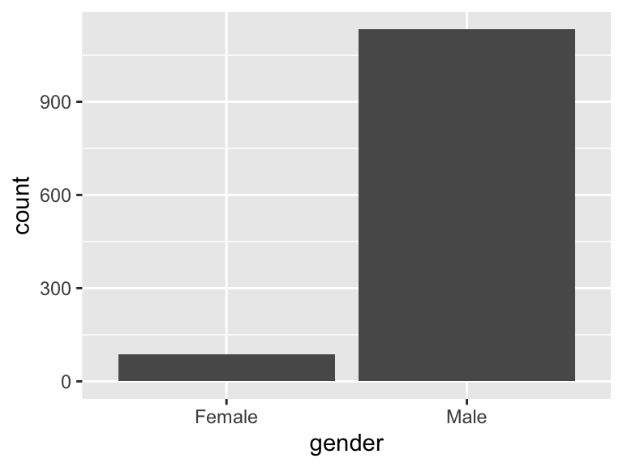

## region

| Feature | Result |
| --- | --- |
| Variable type | character |
| Number of missing obs. | 7 (0.57 %) |
| Number of unique values | 11 |
| Mode | “Gujarāt” |

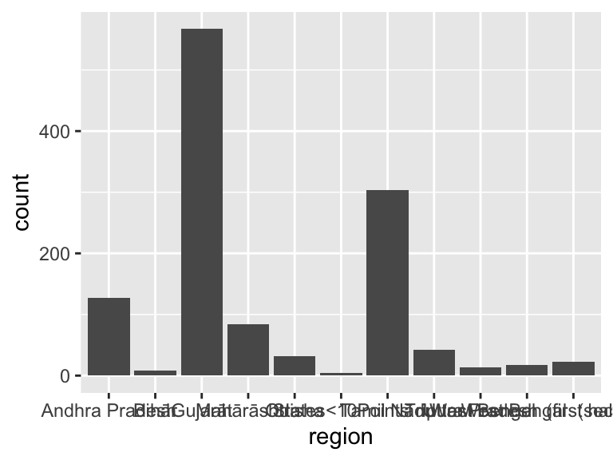

- Note that the following levels have at most five observations: "States<10Points".

## age

| Feature | Result |
| --- | --- |
| Variable type | character |
| Number of missing obs. | 7 (0.57 %) |
| Number of unique values | 3 |
| Mode | “30” |

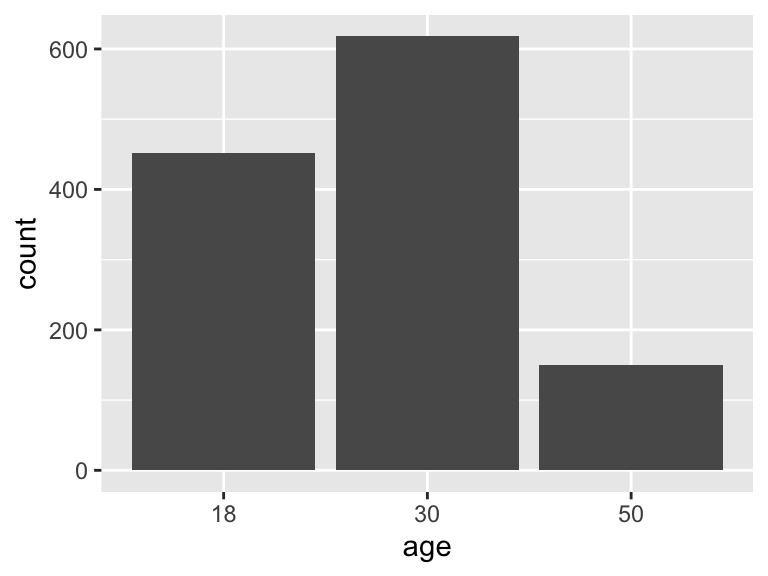

## geo_capability

- The variable only takes one value: "NA".

## geo_status

| Feature | Result |
| --- | --- |
| Variable type | character |
| Number of missing obs. | 0 (0 %) |
| Number of unique values | 3 |
| Mode | “-1” |

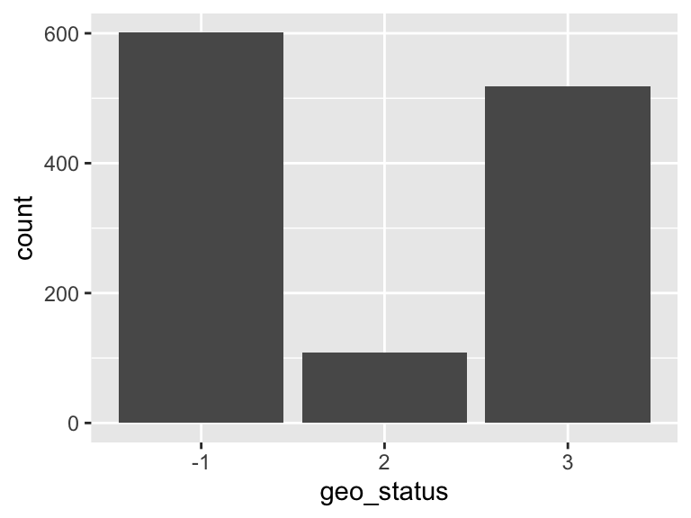

## geo_error

- The variable only takes one (non-missing) value: "error". The variable contains 50.86 % missing observations.

## country

- The variable only takes one value: "NA".

## no_surverys_submitted

- Note that this variable is treated as a factor variable below, as it only takes a few unique values.

| Feature | Result |
| --- | --- |
| Variable type | integer |
| Number of missing obs. | 0 (0 %) |
| Number of unique values | 2 |
| Mode | “1” |
| Reference category | 1 |

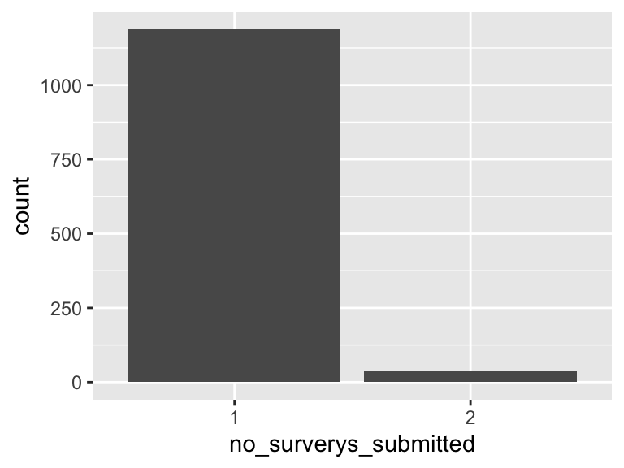

## income_brackets

| Feature | Result |
| --- | --- |
| Variable type | character |
| Number of missing obs. | 32 (2.61 %) |
| Number of unique values | 4 |
| Mode | “0% Tax Rate (Up to Rs. 3,00,000)” |

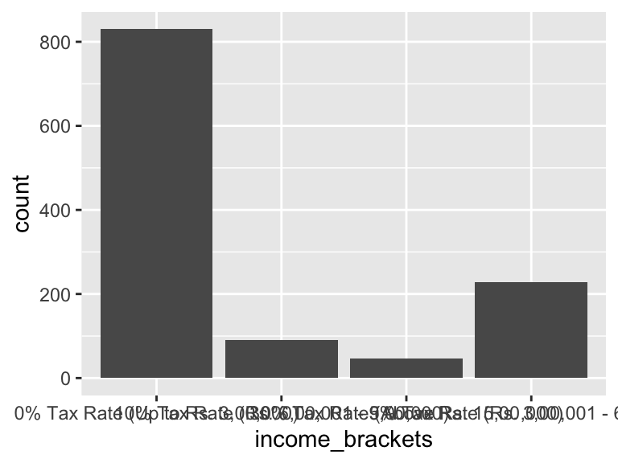

Report generation information:

- Created by: Sofia Ingersoll (username: `sofiaingersoll`).
- Report creation time: Sun Apr 21 2024 22:27:52
- Report was run from directory: `/Users/sofiaingersoll/2035/Adaptation_Observatory/response_analysis/dataMaid`
- dataMaid v1.4.1 [Pkg: 2021-10-08 from CRAN (R 4.3.0)]
- R version 4.3.2 (2023-10-31).
- Platform: aarch64-apple-darwin20 (64-bit)(America/Los_Angeles).
- Function call: `makeDataReport(data = ind, output = "html", replace = TRUE, reportTitle = "India Adaptation Observation Survey Responses, Retrieval Date 15 April 2024.")`